# Assessing Health and Economic Impact of Weather Events

Suriyaprakasam Ramalingam

February 10, 2018

## Synopsis

This study is to analyze the data by U.S. National Oceanic and Atmospheric Administration’s (NOAA) storm database.The data contains type of Storm event with details like location, date, human fatalitties, injuries, damages to the property and Crop and economic impact.

The conclusion is that most human damages (fatalitties and Injuries) cause and most econmic damage(property and Crop) are caused different events. They are not co-related. Tornado is the major cause for fatalities and Injuries.Excessive Heat is the second highiest caise for fatalitties.TSTM Wind is teh second highiest cause for injuries. Flood is the major cause for property damages. Interstingly Drought is the major cause for Crop damage.

## Questions this study considers

1. Across the United States, which types of events (as indicated in the EVTYPE variable) are most harmful with respect to population health?
2. Across the United States, which types of events have the greatest economic consequences?

## Notes about the environment used

This study was done using the following tools, including OS and Programming language versions

The study was conducted on a 64-bit Windows 10 machine with 4 cores.

R language was R version 3.4.0 (2017-04-21)

For publishing to `rpubs.com`, I used RStudio version 1.0.143

The full project may be found on Github at `https://github.com/Suri75/05-reproducible-research-assignment-2`

## Data Processing

Set libraries used in this analysis

```r
library(stringr)
library(ggplot2)
```

## Loading and preprocessing the data

1. Load the data (i.e. read.csv())
2. Process/transform the data (if necessary) into a format suitable for your analysis

```r
# set the Working Directory
setwd('G:/Training/Coursera/Data Science/Reproducible Research/Week 4/')
##Download the data file for the first time
  if(!file.exists("/stormData.csv.bz2")){
      download.file("https://d396qusza40orc.cloudfront.net/repdata%2Fdata%2FStormData.csv.bz2", destfile="./stormData.csv.bz2")
  }
  ##Extract the file once
  if(!file.exists("stormdata.csv"))
  {
    bunzip2("stormData.csv.bz2","stormdata.csv",remove=F)
  }

  ##load the data
  storm <- read.csv("stormdata.csv",header=TRUE,sep=",")
  head(storm)
```

```
##   STATE__           BGN_DATE BGN_TIME TIME_ZONE COUNTY COUNTYNAME STATE
## 1       1  4/18/1950 0:00:00     0130       CST     97     MOBILE    AL
## 2       1  4/18/1950 0:00:00     0145       CST      3    BALDWIN    AL
## 3       1  2/20/1951 0:00:00     1600       CST     57    FAYETTE    AL
## 4       1   6/8/1951 0:00:00     0900       CST     89    MADISON    AL
## 5       1 11/15/1951 0:00:00     1500       CST     43    CULLMAN    AL
## 6       1 11/15/1951 0:00:00     2000       CST     77 LAUDERDALE    AL
##    EVTYPE BGN_RANGE BGN_AZI BGN_LOCATI END_DATE END_TIME COUNTY_END
## 1 TORNADO         0                                               0
## 2 TORNADO         0                                               0
## 3 TORNADO         0                                               0
## 4 TORNADO         0                                               0
## 5 TORNADO         0                                               0
## 6 TORNADO         0                                               0
##   COUNTYENDN END_RANGE END_AZI END_LOCATI LENGTH WIDTH F MAG FATALITIES
```

[output cut: 20 more lines]

## Cleaning the data

As we have to examine maximum cause for property and crop damages. These fields (`PROPDMG`) and (`CROPDMG`). These values are given as integers multiplied by exponential values. not all of the exponent values are valid; many appear to be rounding or entry errors from older entry systems.This analysis treats invalid enries as 0 for the calculations.

## Results

### Question 1: Across the United States, which types of events (as indicated in the EVTYPE variable) are most harmful with respect to population health?

With respect to the Population Health, there are two damages caused : fatalities and injuries. The top 10 severity of the harmful events are analysed and plotted below.

## Fatalities

Aggregate the fatalities by the event type and sort the output in descending order

```r
fatal <- aggregate(FATALITIES~EVTYPE,data=storm,FUN=sum,na.rm=TRUE)
fatal <- fatal[with(fatal,order(-FATALITIES)),]
fatal <- head(fatal,10)
print(fatal)
```

```
##             EVTYPE FATALITIES
## 834        TORNADO       5633
## 130 EXCESSIVE HEAT       1903
## 153    FLASH FLOOD        978
## 275           HEAT        937
## 464      LIGHTNING        816
## 856      TSTM WIND        504
## 170          FLOOD        470
## 585    RIP CURRENT        368
## 359      HIGH WIND        248
## 19       AVALANCHE        224
```

## Injuries

Aggregate the injuries by the event type and sort the output in descending order

```r
injury <- aggregate(INJURIES~EVTYPE,data=storm,FUN=sum,na.rm=TRUE)
injury <- injury[with(injury,order(-INJURIES)),]
injury <- head(injury,10)
print(injury)
```

```
##                EVTYPE INJURIES
## 834           TORNADO    91346
## 856         TSTM WIND     6957
## 170             FLOOD     6789
## 130    EXCESSIVE HEAT     6525
## 464         LIGHTNING     5230
## 275              HEAT     2100
## 427         ICE STORM     1975
## 153       FLASH FLOOD     1777
## 760 THUNDERSTORM WIND     1488
## 244              HAIL     1361
```

## Graph to display top 10 Harmful events for fatalitties and injuries

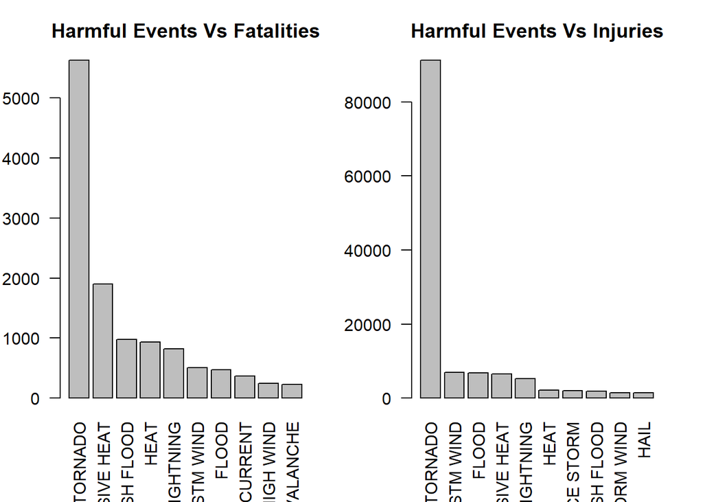

```r
par(mfrow=c(1,2),mar=c(5,3,3,2))
barplot(fatal$FATALITIES,names.arg=fatal$EVTYPE,las=2,col="Grey",ylab="fatalities",main="Harmful Events Vs Fatalities")
barplot(injury$INJURIES,names.arg=injury$EVTYPE,las=2,col="grey",ylab="injuries",main="Harmful Events Vs Injuries")
```

## Harmful Events causing greatest economic consequences

There are two dypes of damages which causes economic consequences.Property damage and Crop damage.

On exploring the column names of the data, we find that the property damage(PROPDMG) and crop damage(CROPDMG) columns has another column(exponents) related to it, i.e PROPDMGEXP and CROPDMGEXP respectively. So, for the calculation of the total property and crop damages caused, we need to convert the exponent columns into numeric data.

```r
storm$PROPDMG[storm$PROPDMGEXP == "K"] <- storm$PROPDMG[storm$PROPDMGEXP == "K"] * 1000
storm$PROPDMG[storm$PROPDMGEXP == "M"] <- storm$PROPDMG[storm$PROPDMGEXP == "M"] * (10^6)
storm$PROPDMG[storm$PROPDMGEXP == "H"] <- storm$PROPDMG[storm$PROPDMGEXP == "H"] * 100
storm$PROPDMG[storm$PROPDMGEXP == "h"] <- storm$PROPDMG[storm$PROPDMGEXP == "h"] * 100
storm$PROPDMG[storm$PROPDMGEXP == ""] <- storm$PROPDMG[storm$PROPDMGEXP == ""] * 1
storm$PROPDMG[storm$PROPDMGEXP == "B"] <- storm$PROPDMG[storm$PROPDMGEXP == "B"] * (10^9)
storm$PROPDMG[storm$PROPDMGEXP == "m"] <- storm$PROPDMG[storm$PROPDMGEXP == "m"] * (10^6)
storm$PROPDMG[storm$PROPDMGEXP == "0"] <- storm$PROPDMG[storm$PROPDMGEXP == "0"] * 1
storm$PROPDMG[storm$PROPDMGEXP == "1"] <- storm$PROPDMG[storm$PROPDMGEXP == "1"] * 10
storm$PROPDMG[storm$PROPDMGEXP == "2"] <- storm$PROPDMG[storm$PROPDMGEXP == "2"] * 100
storm$PROPDMG[storm$PROPDMGEXP == "3"] <- storm$PROPDMG[storm$PROPDMGEXP == "3"] * 1000
storm$PROPDMG[storm$PROPDMGEXP == "4"] <- storm$PROPDMG[storm$PROPDMGEXP == "4"] * (10^4)
storm$PROPDMG[storm$PROPDMGEXP == "5"] <- storm$PROPDMG[storm$PROPDMGEXP == "5"] * (10^5)
storm$PROPDMG[storm$PROPDMGEXP == "6"] <- storm$PROPDMG[storm$PROPDMGEXP == "6"] * (10^6)
storm$PROPDMG[storm$PROPDMGEXP == "7"] <- storm$PROPDMG[storm$PROPDMGEXP == "7"] * (10^7)
storm$PROPDMG[storm$PROPDMGEXP == "8"] <- storm$PROPDMG[storm$PROPDMGEXP == "8"] * (10^8)
storm$PROPDMG[storm$PROPDMGEXP == "+"] <- 0
storm$PROPDMG[storm$PROPDMGEXP == "-"] <- 0
storm$PROPDMG[storm$PROPDMGEXP == "?"] <- 0
head(storm[,c("EVTYPE","PROPDMG","PROPDMGEXP")])
```

```
##    EVTYPE PROPDMG PROPDMGEXP
## 1 TORNADO   25000          K
## 2 TORNADO    2500          K
## 3 TORNADO   25000          K
## 4 TORNADO    2500          K
## 5 TORNADO    2500          K
## 6 TORNADO    2500          K
```

```r
unique(storm$CROPDMGEXP)
```

```
## [1]   M K m B ? 0 k 2
## Levels:  ? 0 2 B k K m M
```

```r
storm$CROPDMG[storm$CROPDMGEXP == "M"] <- storm$CROPDMG[storm$CROPDMGEXP == "M"] * (10^6)
storm$CROPDMG[storm$CROPDMGEXP == "K"] <- storm$CROPDMG[storm$CROPDMGEXP == "K"] * 1000
storm$CROPDMG[storm$CROPDMGEXP == "m"] <- storm$CROPDMG[storm$CROPDMGEXP == "m"] * (10^6)
storm$CROPDMG[storm$CROPDMGEXP == "B"] <- storm$CROPDMG[storm$CROPDMGEXP == "B"] * (10^9)
storm$CROPDMG[storm$CROPDMGEXP == "k"] <- storm$CROPDMG[storm$CROPDMGEXP == "k"] * 1000
storm$CROPDMG[storm$CROPDMGEXP == "0"] <- storm$CROPDMG[storm$CROPDMGEXP == "0"] * 1
storm$CROPDMG[storm$CROPDMGEXP == "2"] <- storm$CROPDMG[storm$CROPDMGEXP == "2"] * 100
storm$CROPDMG[storm$CROPDMGEXP == ""] <- storm$CROPDMG[storm$CROPDMGEXP == ""] * 1
storm$CROPDMG[storm$CROPDMGEXP == "?"] <- 0
head(storm[,c("EVTYPE","CROPDMG","CROPDMGEXP")])
```

```
##    EVTYPE CROPDMG CROPDMGEXP
## 1 TORNADO       0
## 2 TORNADO       0
## 3 TORNADO       0
## 4 TORNADO       0
## 5 TORNADO       0
## 6 TORNADO       0
```

```r
##aggregate the property damage by the event type and sort the output it in descending order
prop <- aggregate(PROPDMG~EVTYPE,data=storm,FUN=sum,na.rm=TRUE)
prop <- prop[with(prop,order(-PROPDMG)),]
prop <- head(prop,10)
print(prop)
```

```
##                EVTYPE      PROPDMG
## 170             FLOOD 144657709807
## 411 HURRICANE/TYPHOON  69305840000
## 834           TORNADO  56947380617
## 670       STORM SURGE  43323536000
## 153       FLASH FLOOD  16822673979
## 244              HAIL  15735267513
## 402         HURRICANE  11868319010
## 848    TROPICAL STORM   7703890550
## 972      WINTER STORM   6688497251
## 359         HIGH WIND   5270046260
```

```r
##aggregate the crop damage by the event type and sort the output it in descending order
crop <- aggregate(CROPDMG~EVTYPE,data=storm,FUN=sum,na.rm=TRUE)
crop <- crop[with(crop,order(-CROPDMG)),]
crop <- head(crop,10)
print(crop)
```

```
##                EVTYPE     CROPDMG
## 95            DROUGHT 13972566000
## 170             FLOOD  5661968450
## 590       RIVER FLOOD  5029459000
## 427         ICE STORM  5022113500
## 244              HAIL  3025954473
## 402         HURRICANE  2741910000
## 411 HURRICANE/TYPHOON  2607872800
## 153       FLASH FLOOD  1421317100
## 140      EXTREME COLD  1292973000
## 212      FROST/FREEZE  1094086000
```

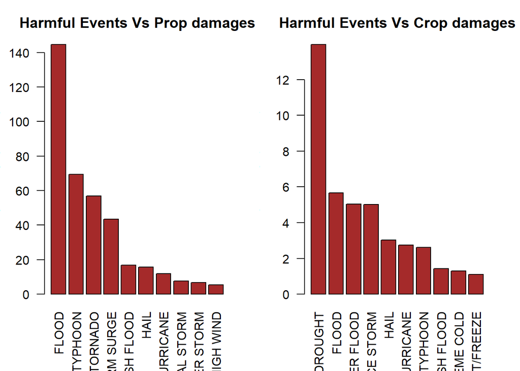

```r
par(mfrow=c(1,2),mar=c(5,3,3,2))
barplot(prop$PROPDMG/(10^9),names.arg=prop$EVTYPE,las=2,col="brown",ylab="Prop damage(billions)",main="Harmful Events Vs Prop damages")
barplot(crop$CROPDMG/(10^9),names.arg=crop$EVTYPE,las=2,col="brown",ylab="Crop damage(billions)",main="Harmful Events Vs Crop damages")
```

## Results

Among the harmful events, Tornado has caused the most Fatalitties and Injuries. Among the harmful events, Flood has caused most of the property damages followed by Hurricane/Typhhon. Most Crop damage was caued by Drought followed by Flood.

## Summary

The data published by U.S. National Oceanic and Atmospheric Administration’s (NOAA) has been analyzed and most of harmful events causes fatalities, injuries and economic consequences has been analyzed.